# 004 Activation Functions Explained

### Detailed Explanation of Each Activation Function

#### 1. Sigmoid (or Logistic)

- **Purpose:**
  - **Binary Classification Output:** It squashes any real-valued number into a range between 0 and 1. This makes it ideal for the output layer in binary classification problems, where the output can be interpreted as the probability of belonging to a certain class.
  - Historically, it was also used in hidden layers.
- **Usage Example:** Predicting whether an email is spam (1) or not spam (0).
- **Why choose it/not choose it?**
  - **Pros:** Outputs are probabilities, easy to understand.
  - **Cons:**
    - **Vanishing Gradient Problem:** For very large positive or very large negative inputs, the slope of the sigmoid function becomes very flat (derivative approaches 0). During backpropagation, these tiny gradients get multiplied down through layers, causing earlier layers to learn very slowly or stop learning altogether. This is a major issue in deep networks.
    - **Not Zero-Centered:** All outputs are positive (between 0 and 1). This can lead to issues during optimization where gradients for weights in successive layers will either be all positive or all negative, causing zigzagging optimization paths and slower convergence.
    - **Computationally Expensive:** The `exp()` function is more costly than simple arithmetic operations.

#### 2. Tanh (Hyperbolic Tangent)

- **Purpose:**
  - Similar to sigmoid but squashes values between -1 and 1.
  - Often preferred over sigmoid for hidden layers.
- **Usage Example:** Hidden layers in recurrent neural networks (RNNs) or older feedforward networks.
- **Why choose it/not choose it?**
  - **Pros:** **Zero-centered output** (outputs range from -1 to 1). This helps in centering the data and can lead to faster convergence during training compared to sigmoid.
  - **Cons:** Still suffers from the **vanishing gradient problem** at the extreme ends of its range (though less severely than sigmoid due to its zero-centered nature).

#### 3. ReLU (Rectified Linear Unit)

- **Purpose:**
  - The most widely used activation function for **hidden layers** in deep learning models today.
  - Introduces non-linearity, allowing the network to learn complex patterns.
- **Usage Example:** Hidden layers in almost all Convolutional Neural Networks (CNNs), many large-scale deep learning models.
- **Why choose it/not choose it?**
  - **Pros:**
    - **Computational Efficiency:** Extremely simple computation (just a `max` operation).
    - **Mitigates Vanishing Gradients:** For positive inputs, the derivative is always 1, allowing gradients to flow easily through the network. This significantly speeds up training convergence compared to sigmoid or tanh.
  - **Cons:**
    - **Dying ReLU Problem:** If a neuron's input is always negative (e.g., due to a large negative bias or certain weight updates), its output will always be 0. Consequently, its gradient will also be 0, meaning it stops learning and effectively "dies" (never activates for any input).
    - Not zero-centered (outputs are always non-negative).

#### 5. ELU (Exponential Linear Unit)

- **Purpose:** Another variant designed to improve upon ReLU.
- **Usage Example:** Hidden layers, especially in deeper networks.
- **Why choose it/not choose it?**
  - **Pros:**
    - Helps alleviate vanishing gradients.
    - Can lead to faster learning and better generalization than ReLU/Leaky ReLU by producing mean activations closer to zero. This helps in reducing the "bias shift" problem and makes the optimization landscape smoother.
    - It can output negative values.
  - **Cons:** Computationally more expensive than ReLU or Leaky ReLU due to the `exp()` function.

#### 6. Softmax

- **Purpose:**
  - **Multi-class Classification Output:** Converts a vector of arbitrary real numbers (logits) into a probability distribution where the sum of probabilities for all classes equals 1.
- **Usage Example:** Output layer for classifying images into "cat", "dog", or "bird."
- **Why choose it/not choose it?**
  - **Pros:** Provides clear, interpretable probabilities for each class. Works perfectly with the standard cross-entropy loss function for multi-class classification.
  - **Cons:** Only suitable for the output layer in multi-class classification, not for hidden layers or binary classification (use Sigmoid for binary).

### General Guidelines for Choosing Activation Functions:

- **For Hidden Layers:**
  - **Start with ReLU.** It's the most common and generally performs well, offering good computational efficiency and alleviating vanishing gradients.
  - If you observe issues like **"dying ReLUs"** (where a significant number of neurons become inactive during training), consider using **Leaky ReLU** or **ELU**.
  - Avoid Sigmoid and Tanh in deep hidden layers due to vanishing gradient issues.
- **For Output Layers:**
  - **Binary Classification:** Use **Sigmoid** (if you want a probability between 0 and 1).
  - **Multi-class Classification:** Use **Softmax** (if you want a probability distribution over multiple classes that sums to 1).
  - **Regression:** Use a **linear activation** (or no activation function at all, which is equivalent to linear) because you want the network to output arbitrary real numbers, not probabilities.

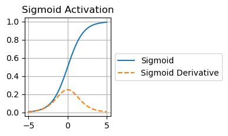

```python
import numpy as np
import matplotlib.pyplot as plt

# Define a range of input values for plotting
x = np.linspace(-5, 5, 100)

# --- 1. Sigmoid Function ---

# Purpose:
#   - Historically popular in hidden layers.
#   - Good for output layer in binary classification tasks (interpretable as probabilities).
# Usage Example:
#   - Binary classification output (e.g., predicting 0 or 1).
# Pros:
#   - Outputs are well-defined between 0 and 1, providing a nice probabilistic interpretation.
# Cons (Why often not used in hidden layers anymore):
#   - Vanishing Gradient Problem: For very large or very small (negative) inputs, the derivative
#     becomes very close to zero. This leads to very small updates to weights during backpropagation,
#     effectively "stopping" learning in deeper layers.
#   - Not "zero-centered": Outputs are always positive, which can lead to issues during optimization
#     (e.g., gradients for weights in successive layers will always be positive or always negative,
#     leading to zigzagging optimization paths).
#   - Computationally expensive due to exp() function.


def sigmoid(z):
    """
    Sigmoid (Logistic) activation function.
    Squashes values between 0 and 1.
    """
    return 1 / (1 + np.exp(-z))

def sigmoid_derivative(z):
    """
    Derivative of the Sigmoid function.
    """
    s = sigmoid(z)
    return s * (1 - s)

# Sigmoid
plt.subplot(2, 3, 1)
plt.plot(x, sigmoid(x), label='Sigmoid')
plt.plot(x, sigmoid_derivative(x), label='Sigmoid Derivative', linestyle='--')
plt.title('Sigmoid Activation')
plt.grid(True)
plt.legend(loc='center left', bbox_to_anchor=(1, 0.5))
```

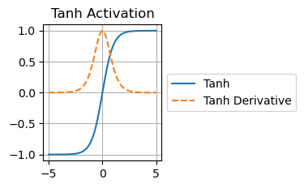

```python
# --- 2. Tanh (Hyperbolic Tangent) Function ---

# Purpose:
#   - Often preferred over sigmoid in hidden layers.
# Usage Example:
#   - Hidden layers of neural networks.
# Pros:
#   - Zero-centered: Outputs are between -1 and 1, which helps in centering the data
#     and can lead to faster convergence during training compared to sigmoid.
#   - Still provides non-linearity.
# Cons:
#   - Still suffers from the vanishing gradient problem for very large or very small inputs.


def tanh(z):
    """
    Tanh (Hyperbolic Tangent) activation function.
    Squashes values between -1 and 1.
    """
    return np.tanh(z)

def tanh_derivative(z):
    """
    Derivative of the Tanh function.
    """
    t = tanh(z)
    return 1 - t**2

# Tanh
plt.subplot(2, 3, 2)
plt.plot(x, tanh(x), label='Tanh')
plt.plot(x, tanh_derivative(x), label='Tanh Derivative', linestyle='--')
plt.title('Tanh Activation')
plt.grid(True)
plt.legend(loc='center left', bbox_to_anchor=(1, 0.5))
```

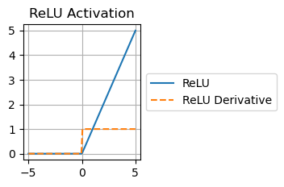

```python
# --- 3. ReLU (Rectified Linear Unit) Function ---

# Purpose:
#   - Most widely used activation function for hidden layers in deep learning.
# Usage Example:
#   - Hidden layers in Convolutional Neural Networks (CNNs) and many other deep architectures.
# Pros:
#   - Computational efficiency: Simple operation (max(0, x)).
#   - Mitigates vanishing gradient problem: For positive inputs, the derivative is always 1,
#     allowing gradients to flow easily.
#   - Speeds up convergence compared to sigmoid/tanh.
# Cons:
#   - Dying ReLU Problem: Neurons can become "dead" during training if their input
#     always remains negative. This leads to the derivative always being zero, and
#     the neuron stops learning.
#   - Not zero-centered.


def relu(z):
    """
    ReLU (Rectified Linear Unit) activation function.
    Output is z if z > 0, else 0.
    """
    return np.maximum(0, z)

def relu_derivative(z):
    """
    Derivative of the ReLU function.
    """
    return np.where(z > 0, 1, 0)

# ReLU
plt.subplot(2, 3, 3)
plt.plot(x, relu(x), label='ReLU')
plt.plot(x, relu_derivative(x), label='ReLU Derivative', linestyle='--')
plt.title('ReLU Activation')
plt.grid(True)
#plt.legend()
plt.legend(loc='center left', bbox_to_anchor=(1, 0.5))
```

Let's dive into the internal workings of the Leaky ReLU activation function!

### The Problem Leaky ReLU Aims to Solve: The "Dying ReLU" Problem

First, it's essential to understand why Leaky ReLU was invented. Its predecessor, the **Rectified Linear Unit (ReLU)**, is defined as:

$f(x) = \max(0, x)$

- **If $x > 0$:** Output is $x$ (linear).
- **If $x \le 0$:** Output is $0$.

While ReLU is very popular because it's computationally efficient and helps mitigate vanishing gradients (since it doesn't saturate for positive inputs), it suffers from a major drawback called the **"Dying ReLU" problem**:

1. **Negative Input, Zero Output:** If a neuron's input ($x$) is always negative, its output will always be 0.
2. **Zero Gradient:** The derivative of ReLU for $x \le 0$ is also 0.
3. **No Learning:** During backpropagation, if a neuron outputs 0, the gradient flowing back through it will also be 0. This means its weights and biases will not be updated.
4. **Permanent Deactivation:** Once a ReLU neuron's weights are adjusted such that its input is consistently negative, it can essentially become "dead" or "inactive" for the rest of the training, never contributing to the learning process again. This reduces the effective capacity of the network.

### How Leaky ReLU Works (Internal Mechanism)

Leaky ReLU modifies the standard ReLU function to address the "Dying ReLU" problem. Instead of outputting a strict zero for negative inputs, it allows a small, non-zero gradient.

The Leaky ReLU function is defined as:

$f(x) = \begin{cases} x & \text{if } x > 0 \\ \alpha x & \text{if } x \le 0 \end{cases}$

Where $\alpha$ (alpha) is a small positive constant, typically a small value like 0.01 or 0.001.

**Let's break down its internal operation step-by-step for a single neuron:**

1. **Input (x):** A neuron receives a weighted sum of its inputs from the previous layer, plus its bias. This is the value $x$.
   - For example, $x = (w_1 \cdot a_1) + (w_2 \cdot a_2) + \dots + (w_n \cdot a_n) + b$ (where $w$ are weights, $a$ are activations from the previous layer, and $b$ is the bias).
2. **Decision Point (Conditional Logic):** The Leaky ReLU function then checks the sign of $x$:
   - **Case 1: If $x > 0$ (Positive Input):**
     - The neuron's output (activation) is simply $x$.
     - `output = x`
     - This behaves exactly like a standard ReLU for positive inputs.
   - **Case 2: If $x \le 0$ (Zero or Negative Input):**
     - The neuron's output (activation) is $x$ multiplied by the small constant $\alpha$.
     - `output = alpha * x`
     - Since $\alpha$ is a small positive number (e.g., 0.01) and $x$ is negative or zero, the output will be a very small negative number or zero.

   **Example:**
   - If $\alpha = 0.01$:
     - If $x = 5$, output = $5$
     - If $x = -2$, output = $0.01 \times -2 = -0.02$
     - If $x = 0$, output = $0.01 \times 0 = 0$

### Internal Workings During Backpropagation (Gradient Calculation)

The magic of Leaky ReLU (and why it solves the dying ReLU problem) becomes clear when we look at its derivative, which is used during backpropagation to update weights.

The derivative of Leaky ReLU with respect to $x$ is:

$\frac{df(x)}{dx} = \begin{cases} 1 & \text{if } x > 0 \\ \alpha & \text{if } x \le 0 \end{cases}$

Let's trace how this affects gradient updates:

1. **For $x > 0$:**
   - The derivative is 1.
   - This means that any gradient signal coming from the subsequent layers ($d\_Loss/d\_Output$) is passed through directly, effectively acting as a "pass-through" for positive activations.
   - Gradients are preserved, helping with deep networks.
2. **For $x \le 0$:**
   - The derivative is $\alpha$ (e.g., 0.01).
   - This is the crucial part! Unlike ReLU, where the derivative is 0 for negative inputs, Leaky ReLU provides a small, non-zero gradient.
   - Even if a neuron is in the "off" state ($x \le 0$), a small gradient can still flow back through it.
   - This tiny gradient allows the weights and biases of that neuron to still be adjusted, even if only slightly.
   - `d_Z_curr = d_A_curr * alpha` (where `d_A_curr` is the gradient from the next layer).
   - This small update gives the neuron a chance to recover and potentially become active again in future iterations, thus **preventing it from "dying."**

**Comparison in Backpropagation:**

- **ReLU:** If $x \le 0$, the gradient for that neuron's input is 0. No weight updates for inputs contributing to that neuron.
- **Leaky ReLU:** If $x \le 0$, the gradient for that neuron's input is `gradient_from_next_layer * alpha`. A small update still occurs, allowing the neuron to "un-die."

### Summary of Leaky ReLU's Internal Advantages:

1. **Prevents Dying ReLUs:** The primary benefit. By providing a small gradient for negative inputs, it ensures that neurons can still learn even if they are in the "off" state.
2. **Computational Efficiency:** Similar to ReLU, it's very fast to compute during both forward and backward passes because it involves simple comparisons and multiplications.
3. **Mitigates Vanishing Gradients (for positive inputs):** Like ReLU, for positive inputs, the gradient is 1, preventing the gradient signal from diminishing as it flows back through many layers.
4. **Simpler than Sigmoid/Tanh:** Avoids the computationally expensive exponential operations of sigmoid/tanh and doesn't suffer from their saturation issues on both ends.

Leaky ReLU is a simple yet effective modification that improves the robustness of neural networks compared to standard ReLU, especially in situations where dying neurons could be a problem. It's often a good alternative to try if you encounter training instability with standard ReLU.

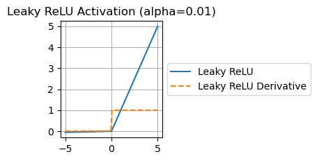

```python
# --- 4. Leaky ReLU Function ---

# Purpose:
#   - An attempt to fix the "dying ReLU" problem.
# Usage Example:
#   - Hidden layers, especially when ReLU causes dead neurons or learning stalls.
# Pros:
#   - Addresses dying ReLU: Allows a small, non-zero gradient for negative inputs,
#     preventing neurons from completely dying.
#   - Retains computational efficiency of ReLU for positive inputs.
# Cons:
#   - Performance isn't always consistent across different tasks compared to ReLU.
#   - The choice of 'alpha' (the leak) can be arbitrary.


def leaky_relu(z, alpha=0.01):
    """
    Leaky ReLU activation function.
    Output is z if z > 0, else alpha * z (where alpha is a small positive constant).
    Addresses the dying ReLU problem.
    """
    return np.maximum(alpha * z, z)

def leaky_relu_derivative(z, alpha=0.01):
    """
    Derivative of the Leaky ReLU function.
    """
    return np.where(z > 0, 1, alpha)

# Leaky ReLU
plt.subplot(2, 3, 4)
plt.plot(x, leaky_relu(x), label='Leaky ReLU')
plt.plot(x, leaky_relu_derivative(x), label='Leaky ReLU Derivative', linestyle='--')
plt.title('Leaky ReLU Activation (alpha=0.01)')
plt.grid(True)
plt.legend(loc='center left', bbox_to_anchor=(1, 0.5))
```

The Exponential Linear Unit (ELU) is another popular activation function in neural networks, designed to combine the benefits of ReLU-like functions while addressing some of their limitations.

It was introduced to help neural networks learn faster and achieve higher classification accuracies.

### The Problem ELU Aims to Solve (and How it Improves):

ELU tackles some issues found in ReLU and even Leaky ReLU:

1. **Dying ReLU Problem:** Like Leaky ReLU, ELU also ensures that neurons don't completely "die" (output zero for negative inputs and thus have zero gradients).
2. **Mean Activation Closer to Zero:** A significant advantage of ELU is that its outputs can be negative. This allows the average activation of a neuron to be closer to zero. Why is this good?
   - **Reduced Bias Shift Effect:** If neuron activations are consistently positive (as with ReLU), it can lead to a "bias shift" in subsequent layers, pushing their inputs towards positive values. This can slow down learning. By having both positive and negative outputs, ELU helps to keep the activations centered around zero, similar to how Batch Normalization helps. This can lead to faster convergence.
3. **Smoothness:** Unlike ReLU and Leaky ReLU, which have a sharp "kink" at $x=0$ (where the derivative changes abruptly), ELU is a **smooth function** for all values, including at $x=0$.
   - **More Robust Optimization:** This smoothness can lead to more robust and stable gradient-based optimization, as there are no sudden changes in the gradient.

### How ELU Works (Internal Mechanism)

The ELU function is defined as:

$f(x) = \begin{cases} x & \text{if } x > 0 \\ \alpha (e^x - 1) & \text{if } x \le 0 \end{cases}$

Where $\alpha$ (alpha) is a positive hyperparameter, typically set to 1.0. $e$ is Euler's number (approximately 2.71828).

Let's break down its internal operation for a single neuron:

1. **Input (x):** A neuron receives a weighted sum of its inputs from the previous layer, plus its bias. This is the value $x$.
2. **Decision Point (Conditional Logic):** The ELU function then checks the sign of $x$:
   - **Case 1: If $x > 0$ (Positive Input):**
     - The neuron's output (activation) is simply $x$.
     - `output = x`
     - This behaves exactly like a standard ReLU for positive inputs, providing a linear response.
   - **Case 2: If $x \le 0$ (Zero or Negative Input):**
     - The neuron's output (activation) is calculated using the exponential term: $\alpha (e^x - 1)$.
     - `output = alpha * (math.exp(x) - 1)`
     - Since $x$ is negative or zero, $e^x$ will be between $0$ (as $x$ approaches $-\infty$) and $1$ (as $x$ approaches $0$).
     - Therefore, $(e^x - 1)$ will be between $-1$ and $0$.
     - The output $\alpha (e^x - 1)$ will be between $-\alpha$ and $0$.
     - As $x$ becomes a very large negative number, $e^x$ approaches $0$, and thus $f(x)$ approaches $-\alpha$. This means ELU **saturates** at a negative value ($-\alpha$) for strongly negative inputs.

   **Example (assuming $\alpha = 1.0$):**
   - If $x = 5$, output = $5$
   - If $x = -0.5$, output = $1.0 \times (e^{-0.5} - 1) \approx 1.0 \times (0.6065 - 1) = -0.3935$
   - If $x = -2$, output = $1.0 \times (e^{-2} - 1) \approx 1.0 \times (0.1353 - 1) = -0.8647$
   - If $x = -10$ (approaching negative infinity), output approaches $1.0 \times (0 - 1) = -1.0$ (saturates at $-\alpha$).
   - If $x = 0$, output = $1.0 \times (e^0 - 1) = 1.0 \times (1 - 1) = 0$. (This also shows its smoothness at $x=0$).

### Internal Workings During Backpropagation (Gradient Calculation)

The derivative of ELU with respect to $x$ is:

$\frac{df(x)}{dx} = \begin{cases} 1 & \text{if } x > 0 \\ \alpha e^x & \text{if } x \le 0 \end{cases}$

Let's trace how this affects gradient updates:

1. **For $x > 0$:**
   - The derivative is 1.
   - Similar to ReLU, the gradient signal from subsequent layers is passed through directly, preserving gradients and aiding in training deep networks.
2. **For $x \le 0$:**
   - The derivative is $\alpha e^x$.
   - Since $e^x$ is always positive and non-zero (it approaches 0 but never reaches it), the gradient $\alpha e^x$ will also always be **positive and non-zero** (ranging from $\alpha$ at $x=0$ to values very close to $0$ as $x$ approaches $-\infty$).
   - This non-zero gradient, even for negative inputs, is critical:
     - It prevents the "dying ReLU" problem by allowing weights to be updated even when the neuron is not highly active.
     - The gradient gradually approaches zero for very negative inputs (due to $e^x$ approaching 0). This "saturation" in the negative region helps in making the model more robust to noise or small variations in input for strongly deactivated neurons.

**Comparison with Leaky ReLU:**

- **Leaky ReLU:** Uses a constant slope ($\alpha$) for negative inputs. This means the gradient is always $\alpha$ for $x \le 0$.
- **ELU:** Uses an exponential curve ($\alpha e^x$) for negative inputs. The slope for negative inputs is not constant; it smoothly changes, approaching zero as $x$ becomes more negative.

### Advantages of ELU:

1. **Prevents Dying ReLUs:** Guarantees a non-zero gradient for negative inputs.
2. **Faster Learning (Mean Activation Closer to Zero):** By allowing negative outputs and having a mean activation closer to zero, ELU helps the network converge faster. This is due to a reduced "bias shift" effect, which can make the optimization landscape easier to navigate.
3. **Smoothness:** Being a continuous and differentiable function (including at $x=0$) makes gradient-based optimization more stable and robust compared to ReLU and Leaky ReLU, which have a sharp point at zero.
4. **Noise Robustness:** The saturation for very negative inputs ($-\alpha$) helps ELU be more robust to noise, as extreme negative values are capped.

### Disadvantages of ELU:

1. **Computational Cost:** The exponential operation ($e^x$) for negative inputs is more computationally expensive than the simple linear operation in ReLU or Leaky ReLU. This can slightly slow down both forward and backward passes.
2. **No Learning of $\alpha$:** The $\alpha$ parameter is a fixed hyperparameter that needs to be tuned, unlike in PReLU where the $\alpha$ is learned.

Overall, ELU is a powerful activation function that often outperforms ReLU and Leaky ReLU, particularly in deeper networks, due to its ability to handle negative activations, maintain a near-zero mean activation, and provide a smooth, non-zero gradient for all inputs.

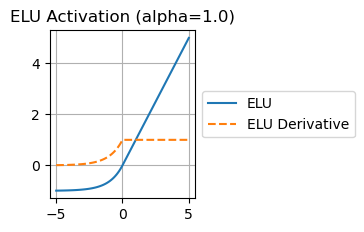

```python
# --- 5. ELU (Exponential Linear Unit) Function ---

# Purpose:
#   - Similar to Leaky ReLU but aims to make the mean activation closer to zero,
#     which can speed up learning.
# Usage Example:
#   - Hidden layers, particularly in deeper networks.
# Pros:
#   - Helps alleviate the vanishing gradient problem.
#   - Can lead to faster convergence than ReLU or Leaky ReLU.
#   - Outputs can go negative, pushing mean activations closer to zero, which can
#     help in reducing the "bias shift" problem (similar to batch normalization).
# Cons:
#   - Computationally more expensive than ReLU or Leaky ReLU due to the exp() function.


def elu(z, alpha=1.0):
    """
    ELU (Exponential Linear Unit) activation function.
    Output is z if z > 0, else alpha * (exp(z) - 1).
    """
    return np.where(z > 0, z, alpha * (np.exp(z) - 1))

def elu_derivative(z, alpha=1.0):
    """
    Derivative of the ELU function.
    """
    return np.where(z > 0, 1, alpha * np.exp(z))

# ELU
plt.subplot(2, 3, 5)
plt.plot(x, elu(x), label='ELU')
plt.plot(x, elu_derivative(x), label='ELU Derivative', linestyle='--')
plt.title('ELU Activation (alpha=1.0)')
plt.grid(True)
plt.legend(loc='center left', bbox_to_anchor=(1, 0.5))
```

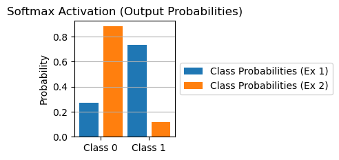

```python
# --- 6. Softmax Function (primarily for output layers in multi-class classification) ---

# Note: Softmax derivative is more complex and typically computed as part of the
# cross-entropy loss derivative, not often needed as a standalone function.
# For simplicity in this context, we won't provide a direct derivative for plotting.

# Purpose:
#   - Converts raw output scores (logits) from the network into probabilities
#     that sum to 1 across all classes.
# Usage Example:
#   - Output layer for multi-class classification (e.g., classifying images into
#     "cat", "dog", "bird").
# Pros:
#   - Provides a clear probability distribution, making the output interpretable.
#   - Works well with cross-entropy loss for classification.
# Cons:
#   - Only used in the output layer, not typically in hidden layers.


def softmax(z):
    """
    Softmax activation function.
    Converts a vector of numbers into a probability distribution.
    Typically used in the output layer for multi-class classification.
    """
    # Subtract max for numerical stability to prevent overflow with large exponents
    exp_z = np.exp(z - np.max(z, axis=-1, keepdims=True))
    return exp_z / np.sum(exp_z, axis=-1, keepdims=True)

# Softmax (Plotting for a 2-element vector example)
z_softmax = np.array([[1.0, 2.0], [3.0, 1.0], [0.5, -0.5]]) # Example input vectors
softmax_output = softmax(z_softmax)
plt.subplot(2, 3, 6)
plt.bar(np.arange(z_softmax.shape[1]), softmax_output[0], width=0.4, label='Class Probabilities (Ex 1)')
plt.bar(np.arange(z_softmax.shape[1]) + 0.5, softmax_output[1], width=0.4, label='Class Probabilities (Ex 2)')
plt.title('Softmax Activation (Output Probabilities)')
plt.xticks([0.25, 1.25], ['Class 0', 'Class 1'])
plt.ylabel('Probability')
plt.grid(axis='y')
plt.legend(loc='center left', bbox_to_anchor=(1, 0.5))
```

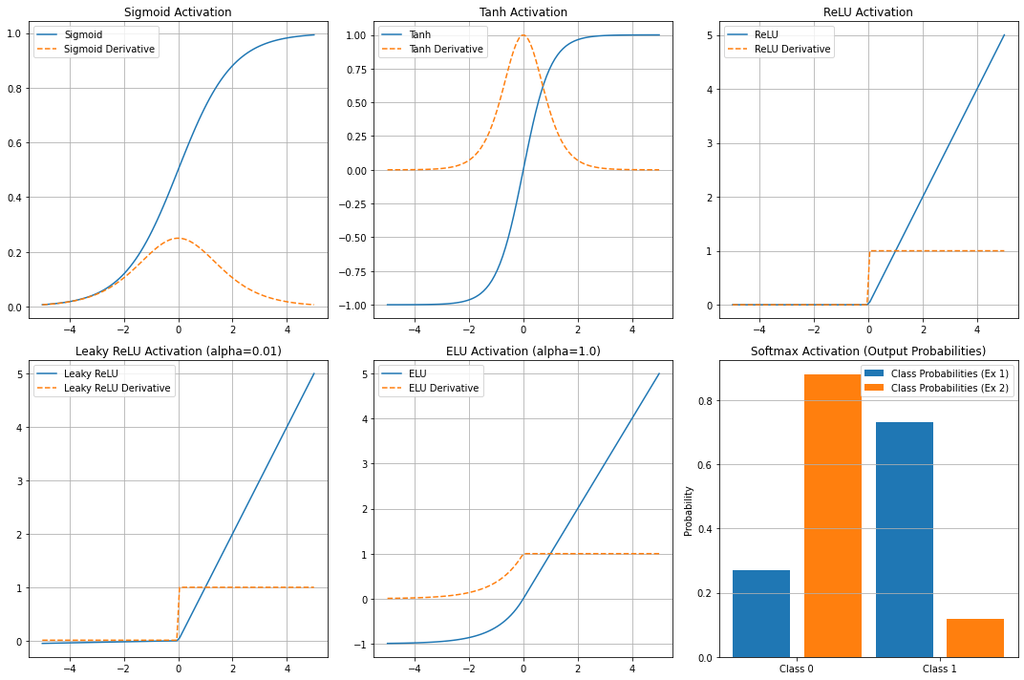

```python
# --- Plotting the Functions ---
plt.figure(figsize=(15, 10))

# Sigmoid
plt.subplot(2, 3, 1)
plt.plot(x, sigmoid(x), label='Sigmoid')
plt.plot(x, sigmoid_derivative(x), label='Sigmoid Derivative', linestyle='--')
plt.title('Sigmoid Activation')
plt.grid(True)
plt.legend()

# Tanh
plt.subplot(2, 3, 2)
plt.plot(x, tanh(x), label='Tanh')
plt.plot(x, tanh_derivative(x), label='Tanh Derivative', linestyle='--')
plt.title('Tanh Activation')
plt.grid(True)
plt.legend()

# ReLU
plt.subplot(2, 3, 3)
plt.plot(x, relu(x), label='ReLU')
plt.plot(x, relu_derivative(x), label='ReLU Derivative', linestyle='--')
plt.title('ReLU Activation')
plt.grid(True)
plt.legend()

# Leaky ReLU
plt.subplot(2, 3, 4)
plt.plot(x, leaky_relu(x), label='Leaky ReLU')
plt.plot(x, leaky_relu_derivative(x), label='Leaky ReLU Derivative', linestyle='--')
plt.title('Leaky ReLU Activation (alpha=0.01)')
plt.grid(True)
plt.legend()

# ELU
plt.subplot(2, 3, 5)
plt.plot(x, elu(x), label='ELU')
plt.plot(x, elu_derivative(x), label='ELU Derivative', linestyle='--')
plt.title('ELU Activation (alpha=1.0)')
plt.grid(True)
plt.legend()

# Softmax (Plotting for a 2-element vector example)
z_softmax = np.array([[1.0, 2.0], [3.0, 1.0], [0.5, -0.5]]) # Example input vectors
softmax_output = softmax(z_softmax)
plt.subplot(2, 3, 6)
plt.bar(np.arange(z_softmax.shape[1]), softmax_output[0], width=0.4, label='Class Probabilities (Ex 1)')
plt.bar(np.arange(z_softmax.shape[1]) + 0.5, softmax_output[1], width=0.4, label='Class Probabilities (Ex 2)')
plt.title('Softmax Activation (Output Probabilities)')
plt.xticks([0.25, 1.25], ['Class 0', 'Class 1'])
plt.ylabel('Probability')
plt.grid(axis='y')
plt.legend()

plt.tight_layout()
plt.show()
```

```python
# --- Why one over the other? (Summary) ---

print("\n--- Why Choose One Activation Function Over Another? ---")
print("\n1. Sigmoid:")
print("   - Use: Output layer for binary classification (probabilistic output).")
print("   - Avoid: Hidden layers in deep networks (vanishing gradients, not zero-centered).")

print("\n2. Tanh:")
print("   - Use: Hidden layers, especially if you need zero-centered output and are okay with some vanishing gradient risk.")
print("   - Avoid: Very deep networks (still susceptible to vanishing gradients).")

print("\n3. ReLU:")
print("   - Use: Default choice for hidden layers in most deep learning models (fast, mitigates vanishing gradients).")
print("   - Consider alternatives: If you encounter 'dying ReLUs' (neurons consistently outputting zero and not learning).")

print("\n4. Leaky ReLU / PReLU / RReLU:")
print("   - Use: If ReLU causes dying neurons. Offers a small gradient for negative inputs.")
print("   - Trade-off: Slightly more complex than ReLU, performance can vary.")

print("\n5. ELU:")
print("   - Use: In deeper networks, can lead to faster learning and better performance than ReLU/Leaky ReLU.")
print("   - Trade-off: Computationally more expensive due to exp() function.")

print("\n6. Softmax:")
print("   - Use: Exclusively for the output layer in multi-class classification problems.")
print("   - Avoid: Hidden layers or binary classification (use sigmoid for binary).")

print("\n--- General Guidelines: ---")
print(" - **Start with ReLU** for hidden layers in most deep networks.")
print(" - **If ReLU issues arise**, consider Leaky ReLU, ELU, or other variants.")
print(" - **For output layers:**")
print("   - **Binary Classification:** Sigmoid (for probability between 0 and 1).")
print("   - **Multi-class Classification:** Softmax (for probability distribution summing to 1).")
print("   - **Regression:** Often no activation (identity function) or linear activation, as you want to predict arbitrary real numbers.")
```

```
--- Why Choose One Activation Function Over Another? ---

1. Sigmoid:
   - Use: Output layer for binary classification (probabilistic output).
   - Avoid: Hidden layers in deep networks (vanishing gradients, not zero-centered).

2. Tanh:
   - Use: Hidden layers, especially if you need zero-centered output and are okay with some vanishing gradient risk.
   - Avoid: Very deep networks (still susceptible to vanishing gradients).

3. ReLU:
   - Use: Default choice for hidden layers in most deep learning models (fast, mitigates vanishing gradients).
   - Consider alternatives: If you encounter 'dying ReLUs' (neurons consistently outputting zero and not learning).

4. Leaky ReLU / PReLU / RReLU:
   - Use: If ReLU causes dying neurons. Offers a small gradient for negative inputs.
   - Trade-off: Slightly more complex than ReLU, performance can vary.

5. ELU:
   - Use: In deeper networks, can lead to faster learning and better performance than ReLU/Leaky ReLU.
   - Trade-off: Computationally more expensive due to exp() function.

6. Softmax:
   - Use: Exclusively for the output layer in multi-class classification problems.
   - Avoid: Hidden layers or binary classification (use sigmoid for binary).

--- General Guidelines: ---
 - **Start with ReLU** for hidden layers in most deep networks.
 - **If ReLU issues arise**, consider Leaky ReLU, ELU, or other variants.
 - **For output layers:**
   - **Binary Classification:** Sigmoid (for probability between 0 and 1).
   - **Multi-class Classification:** Softmax (for probability distribution summing to 1).
   - **Regression:** Often no activation (identity function) or linear activation, as you want to predict arbitrary real numbers.
```